# Financial Sentiment with Limited Labels

Text classification on Financial PhraseBank

Xianrui Cao · Cherryl Chico · Xiaoyan Wang · Elvis Casco

22DM015 Advanced Methods in NLP

2026-06-25

## The task

Sentence-level **financial sentiment** — classify a news sentence as **negative / neutral / positive**.

- **Dataset:** Financial PhraseBank (`takala/financial_phrasebank`) — ~2,300 sentences, `allagree` config (unanimous annotators).
- **Business case:** signal extraction — an analyst desk or trading system flags negative/positive headlines automatically.
- **Annotation guideline:** labels reflect the *viewpoint of an investor* — each sentence is judged by its likely impact on the **future stock price**

| Class | Example sentence |
| --- | --- |
| negative | “Operating profit *fell* to EUR 35.4 mn from EUR 68.8 mn.” |
| neutral | “The company has its head office in Helsinki.” |
| positive | “Operating profit *rose* to EUR 14.5 mn from EUR 10.2 mn.” |

## Why the data is tricky

**1. Imbalanced**

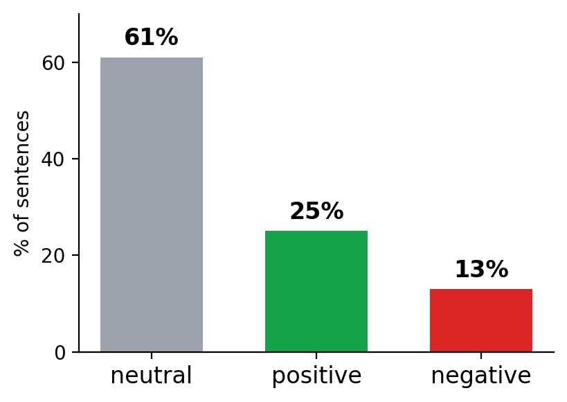

**2. Contextual, not lexical**

- The data contains **financial words with inherent polarity**, and that **polarity can switch depending on the directional word** it is used with.

financial word · directional word

- **positive** — net sales increased by 5.2% to EUR 205.5 mn, and operating profit by 34.9% to EUR 23.5 mn.
- **negative** — the growth margin slowed down due to the financial crisis.
- **neutral** — Tiimari … generated a turnover of 76.5 mln eur in 2005.

## Data preparation & augmentation

**Split & few-shot set**

- **70 / 10 / 20** train / val / test, **stratified by sentiment**
- **Balanced 32-label set** sampled from *train*

**Two augmentations from the 32**

- **Back-translation (no LLM)** — MarianMT through **7 pivot languages** (es, de, ru, fi, tl, ar, zh)
- **LLM-generated** — Groq `llama-3.3-70b`, **temp 0.95** for variety with 3 same-class anchors per call
  - **Prompt** — mimic FPB single-sentence news; label from the **investor’s POV**; vary sentiment *strength*; **fictional-but-realistic** company names.

**Did the augmentation meet our criteria?**

| Criterion | Back-translation | LLM |
| --- | --- | --- |
| New sentences | 197 | **360** |
| Sentiment preserved | ✅ | ✅ |
| Numbers preserved | ✅ guard | ✅ prompt |
| Lexical diversity (new words) | ~200 | **~1000** |
| Structural variety (distinct-3) | 0.57 | **0.83** |

*distinct-3 = unique trigrams ÷ total trigrams (1 = all distinct, 0 = all repeated).*

## Benchmarks: floor and ceiling

| Benchmark | macro-F1 | F1-negative | F1-neutral | F1-positive |
| --- | --- | --- | --- | --- |
| Always neutral | 0.253 | 0.000 | 0.761 | 0.000 |
| Prior-weighted random | 0.328 | 0.108 | 0.604 | 0.273 |
| **FinBERT**<sup>1</sup> | **0.95** | — | — | — |

[^1]: Araci (2019), *FinBERT: Financial Sentiment Analysis with Pre-trained Language Models*, arXiv:1908.10063 — BERT further-pretrained on a financial corpus, then fine-tuned on Financial PhraseBank. Macro-F1 reported on the 100%-agreement subset.

## A directional rule already goes a long way

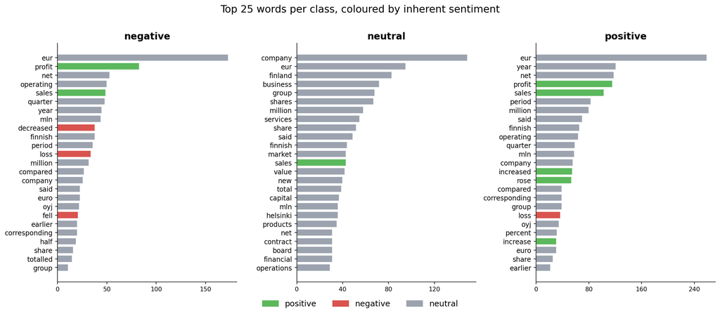

- The **directional words** already separate the classes while inherently-polar financial words show up across **all three**, thus a **rule-based lexicon**.

## Benchmarks: the rule-based lexicon slots in

| Benchmark | macro-F1 | F1-negative | F1-neutral | F1-positive |
| --- | --- | --- | --- | --- |
| Always neutral | 0.253 | 0.000 | 0.761 | 0.000 |
| Prior-weighted random | 0.328 | 0.108 | 0.604 | 0.273 |
| **Rule-based lexicon** | **0.788** | **0.815** | **0.876** | 0.674 |
| FinBERT<sup>1</sup> | 0.95 | — | — | — |

[^2]: Araci (2019), arXiv:1908.10063 — BERT pretrained on a financial corpus, fine-tuned on FPB; macro-F1 on the 100%-agreement subset.

## Where the rule misses

The misses are the cases direction alone can’t reach — they need a **language model**. (financial word · directional word)

**TRUE negative** → **PRED neutral** ✗ — **direction implied, not stated**

> Operating loss totalled EUR 12.7 mn, compared to a profit of EUR 17.7 mn in the first half of 2008.

**TRUE neutral** → **PRED positive** ✗ — **direction unrelated to the financial word**

> These developments partly reflect the government’s higher activity in the field of dividend policy.

**TRUE positive** → **PRED neutral** ✗ — **no direction at all**

> KONE … received a major order to supply all elevators and escalators for the Watermark Place project in London.

## Models with 32 labels

| Technique | n | macro-F1 |
| --- | --- | --- |
| Frozen BERT + linear probe | 32 | 0.379 |
| **BERT fine-tuned (full)** | 32 | **0.554** |
| Back-translation augment | 229 | 0.716 |
| *Rule-based baseline* | — | *0.788* |
| **LLM-generated data → BERT** | 392 | **0.874** |
| LLM zero-shot (Claude) | 0 | 0.978 |

- **Few-shot BERT loses to the lexicon.** Fine-tuning a 110M model on 32 examples is the wrong tool — SetFit would be right.
- **Freeze finding:** frozen body ≈ random (0.379). The signal comes from *adapting the body*, not the head.
- **Back-translation:** paraphrasing adds no new information → still below rules.
- **What worked:** LLM-*generated* new labelled data (`llama-3.3-70b`) → **0.874**, best Part-2 BERT. Information, not model size, was the bottleneck.

## The data-scaling curve

How much data does BERT actually need? Train on 1 / 10 / 25 / 50 / 75 / 100%.

| Fraction | ~labels | macro-F1 |
| --- | --- | --- |
| 1% | 15 | **0.479** ← collapse |
| 10% | 158 | **0.879** ← beats rules |
| 25% | 396 | 0.944 |
| 50% | 792 | 0.960 |
| 75% | 1188 | 0.960 |
| 100% | 1584 | **0.958** |

- **Steep climb, then a noisy plateau.** Only collapse is at 1% (15 labels) — the imbalance trap, not a phase transition.
- **Rules → BERT crossover by ~158 labels** (10% BERT 0.879 > rules 0.788). Most gains realised by ~25%; flat and noisy after.
- Full data **0.958** comes within ~2 points of the LLM’s 0.978 — **closes most of the gap, does not tie.** (Protocol: 20 epochs, maxlen 128, single seed.)

## Synthesis: the right tool per label budget

**The thesis**

The LLM keeps a ~1–2 point edge — but that edge **shrinks as labels grow** and is itself suspect (below).

**Why the gap is smaller than it looks — the LLM’s 0.978 is suspicious**

1. **Contamination** — FPB is a public 2014 benchmark, almost certainly in pretraining → partly memorisation, so 0.978 is likely inflated.
2. **Few-shot lever inert** — adding our 32 examples in-context changed **zero** predictions.
3. **Black-box, paid, latency** — not reproducible without a cache.

The near-matching BERT (0.958, up to 0.965 with LLM-gen data) is free, offline, deterministic, auditable, contamination-free. **Within ~2 points — and the one you can actually ship.**

## Deployment, limitations & next steps

**Part 4 — compression (5-seed means)**

| Model | Size | Speed | macro-F1 |
| --- | --- | --- | --- |
| Teacher BERT | 1× | 1× | 0.958 |
| **DistilBERT (distill)** | ~½ | ~1.7× | 0.943 |
| **int8 (quantize)** | ~2.4× smaller | *slower* | ~0.957 |

- Distillation = lever for **speed** (small, real quality cost).
- Quantization buys **memory, not latency** on this hardware.

**Honest limitations**

- BERT curve = **single seed** (20 epochs, maxlen 128) → read the plateau as a noisy trend.
- `allagree` is the **easiest** config → numbers soften on ambiguous data.
- LLM 0.978 = a **likely-contaminated upper bound**.

**Next steps**

- SetFit for the 32-label regime.
- Multiple seeds + confidence bands.
- Domain-pretrained FinBERT vs base BERT.

## Takeaways

- **The right model depends on the label budget, not on a leaderboard.**
- At 32 labels a **free lexicon beats fine-tuned BERT** — so don’t fine-tune at 32 labels.
- BERT **beats the rules by ~158 labels** and at full data reaches **0.958 (up to 0.965 with LLM-gen data)** — within ~2 points of the zero-shot LLM (0.978), locally, auditably, contamination-free.
- The LLM keeps a small edge — but it **shrinks as labels grow** and likely reflects **benchmark contamination**, so the local model is the one you can trust and ship.

**Thank you — happy to take questions.**

## Backup — full scoreboard

| Model | Labels | macro-F1 | Notes |
| --- | --- | --- | --- |
| Random | — | 0.328 | floor |
| Majority neutral | — | 0.25 (acc 0.61) | no skill |
| Rule-based lexicon | 0 | 0.788 | strong neg, weak pos |
| Frozen BERT probe | 32 | 0.379 | ≈ random |
| BERT fine-tuned | 32 | 0.554 | loses to rules |
| Back-translation → BERT | 229 | 0.716 | no new info |
| LLM-generated → BERT | 392 | 0.874 | best Part-2 |
| BERT (full data) | 1584 | 0.958 | within ~2 pts of LLM |
| BERT + LLM-gen (full) | 1944 | 0.965 | best local |
| LLM zero-shot (Claude) | 0 | 0.978 | contamination caveat |

## Backup — per-class diagnostics

**Rule-based baseline — where it fails**

- NEGATIVE F1 **0.815** (strong) · NEUTRAL strong · POSITIVE F1 **0.674** (weak)
- Failure mode: positives leak into neutral (financial positivity is phrased indirectly).

**Low-data BERT — opposite failure**

- Collapses toward the **majority (neutral)** class at small fractions.

> Per-class F1 is the single best diagnostic in the project — it shows *which* class each model misses, which a single macro number hides.